# skyscapeR: Data Analysis and Visualization for Skyscape Archaeology

## 3. The Discrete Approach

### 3.1 Polar plots

Once azimuths are given (and presumably corrected) one can visualize them using `plotAzimuth`.

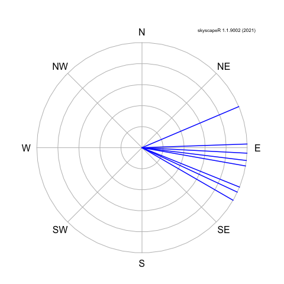

```r
az <- c(120, 100, 93, 97, 88, 115, 112, 67)
plotAzimuth(az)
```

To visualize these against the common solar and lunar targets function `sky.objects` should be used to choose the celestial targets and how one wants to visualize them. This can be done as follows:

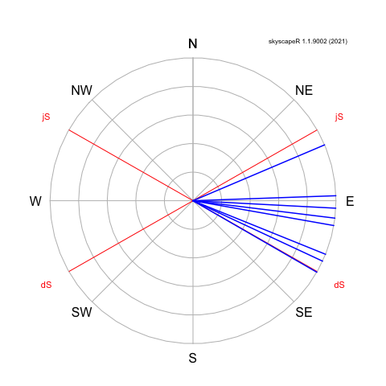

```r
tt <- sky.objects('solar extremes', epoch=-2000, loc=c(35,-8), col='red')
plotAzimuth(az, obj=tt)
```

Although one can also produce a plot of only the celestial targets:

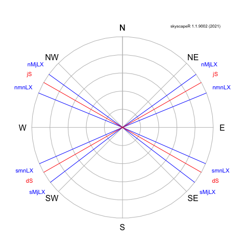

```r
tt <- sky.objects(c('solar extremes', 'lunar extremes'), epoch=-2000, loc=c(35,-8), col=c('red','blue'))
plotAzimuth(obj=tt)
```

Measurement color and width can be controlled using parameters `col` and `lwd`.

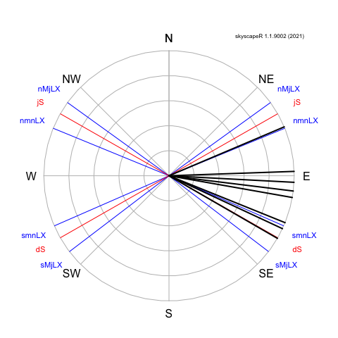

```r
plotAzimuth(az, obj=tt, lwd=2, col='black')
```

### 3.2 Density plots

Density plots, such as curvigrams and kernel density estimates, can be obtained using the base R `density` function. This works for both azimuth and declination data. However, do note that these differ from the more accurate SPD plots that are covered in the next section.

```r
az <- c(120, 100, 93, 97, 88, 115, 112, 67)
hor <- createHWT(51.17889, 1.826111, name='Stonehenge')
```

```
#> Sending request to HeyWhatsThat servers...Done.
#> Waiting for computation to finish...Done.
```

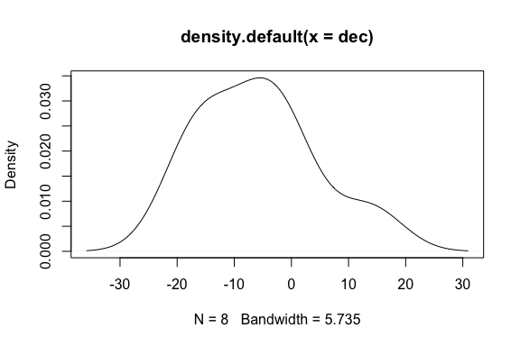

```r
dec <- az2dec(az, loc=hor)
kde <- density(dec)
plot(kde)
```

The kernel shape and bandwidth (uncertainty) can also be controlled as follows. For more details check the manual pages for `density`.

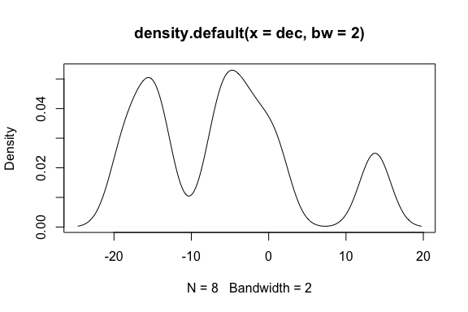

```r
kde <- density(dec, bw=2) # forces uncertainty to be a given value, in this case 2 degrees
plot(kde)
```

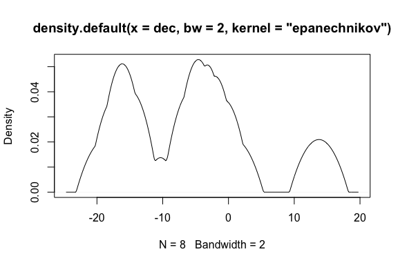

```r
kde <- density(dec, bw=2, kernel='epanechnikov') # changes kernel to epanechnikov
plot(kde)
```

### 3.3 Probabilities

The probability of finding `r` structures out of `n` orientated to a band of the horizon of probability `p` can be calculated using the `bernoulli.trial` function. In the above example there are 4 structures (out of 8 measured) which are orientated around east, spanning 12 degrees of azimuth. The probability `p` of that horizon band is `12/180` as there are 12 degrees out of 180 degrees (since both directions are possible). The probability of finding this (or an even more extreme situation) by chance is:

```r
bernoulli.trial(n=8, p=12/180, r=4)
```

```
#> [1] 0.001111395
```

The obtained p-value is well below 0.05 making this statistically significant.